# EDA - Practice Project

Joseph Pushnam

2024-09-29

### 1 **Introduction: Statement of the Business and Analytic Problems**

The primary objective of this project is to predict loan default risk using data from loan applicants, helping the business to make informed decisions and mitigate financial risk associated with loan approvals. The dataset includes various demographic, financial, and loan-specific features, and the target variable (`TARGET`) indicates whether an applicant has defaulted on their loan (`1` for default, `0` for no default).

To understand the data and its potential for predictive modeling, the following key questions are addressed in the Exploratory Data Analysis (EDA):

#### 1.1 **Questions Addressed in the EDA:**

**Is the target variable (loan default) imbalanced, and what would be the accuracy of a simple majority class classifier?**

[output not shown]

**What is the relationship between the target and the predictors? Are there potentially strong predictors that could be included in a model?**

```
-   We investigate correlations and other relationships between the target and key predictors, looking for features that may strongly influence loan default. Identifying strong predictors at this stage helps in feature selection and engineering for future modeling.
```

**How can the `skimr` and `janitor` packages in R assist with data exploration and cleaning?**

[output not shown]

**What is the scope of missing data, and what are the possible solutions? Should we remove rows, remove columns, or impute missing values?**

[output not shown]

### 2 **Brief Exploratory Data Analysis**

#### 2.1 **Checking for Class Imbalance:**

```r
# Set CRAN mirror
options(repos = c(CRAN = "https://cran.rstudio.com/"))

# Load libraries
library(skimr)
library(janitor)
```

```r
library(ggplot2)

# Set working directory
setwd("C:\\Users\\Joseph\\OneDrive\\Desktop\\UoU\\DB_R\\3. Fall 2024\\Practice Project")

# Read the dataset
train_data <- read.csv("application_train.csv")

# Count of target classes
table(train_data$TARGET)
```

```
##
##      0      1
## 282686  24825
```

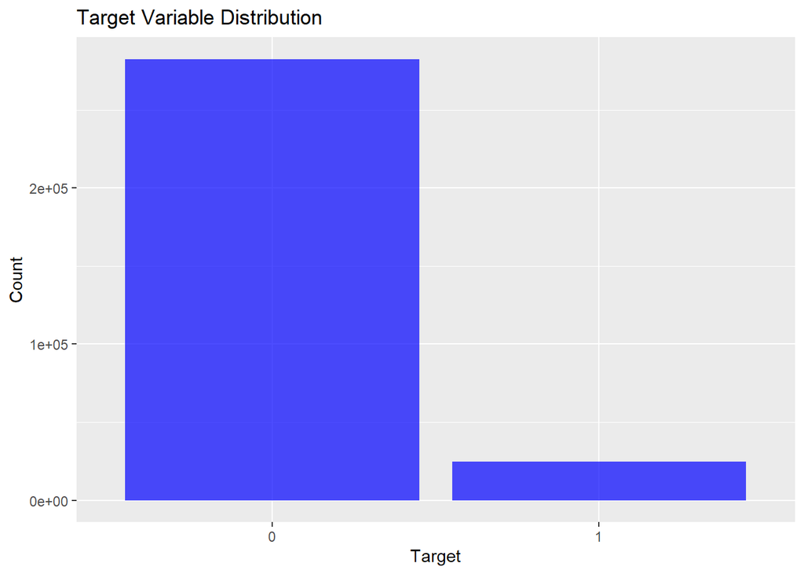

```r
# Plotting the distribution
ggplot(train_data, aes(x = as.factor(TARGET))) +
  geom_bar(fill = "blue", alpha = 0.7) +
  labs(title = "Target Variable Distribution", x = "Target", y = "Count")
```

```r
# Summary of the data
summary(train_data)
```

```
##    SK_ID_CURR         TARGET        NAME_CONTRACT_TYPE CODE_GENDER
##  Min.   :100002   Min.   :0.00000   Length:307511      Length:307511
##  1st Qu.:189146   1st Qu.:0.00000   Class :character   Class :character
##  Median :278202   Median :0.00000   Mode  :character   Mode  :character
##  Mean   :278181   Mean   :0.08073
##  3rd Qu.:367143   3rd Qu.:0.00000
##  Max.   :456255   Max.   :1.00000
##
##  FLAG_OWN_CAR       FLAG_OWN_REALTY     CNT_CHILDREN     AMT_INCOME_TOTAL
##  Length:307511      Length:307511      Min.   : 0.0000   Min.   :    25650
##  Class :character   Class :character   1st Qu.: 0.0000   1st Qu.:   112500
##  Mode  :character   Mode  :character   Median : 0.0000   Median :   147150
##                                        Mean   : 0.4171   Mean   :   168798
##                                        3rd Qu.: 1.0000   3rd Qu.:   202500
##                                        Max.   :19.0000   Max.   :117000000
##
##    AMT_CREDIT       AMT_ANNUITY     AMT_GOODS_PRICE   NAME_TYPE_SUITE
##  Min.   :  45000   Min.   :  1616   Min.   :  40500   Length:307511
##  1st Qu.: 270000   1st Qu.: 16524   1st Qu.: 238500   Class :character
##  Median : 513531   Median : 24903   Median : 450000   Mode  :character
##  Mean   : 599026   Mean   : 27109   Mean   : 538396
##  3rd Qu.: 808650   3rd Qu.: 34596   3rd Qu.: 679500
##  Max.   :4050000   Max.   :258026   Max.   :4050000
##                    NA's   :12       NA's   :278
##  NAME_INCOME_TYPE   NAME_EDUCATION_TYPE NAME_FAMILY_STATUS NAME_HOUSING_TYPE
##  Length:307511      Length:307511       Length:307511      Length:307511
##  Class :character   Class :character    Class :character   Class :character
##  Mode  :character   Mode  :character    Mode  :character   Mode  :character
##
##
##
##
##  REGION_POPULATION_RELATIVE   DAYS_BIRTH     DAYS_EMPLOYED    DAYS_REGISTRATION
##  Min.   :0.00029            Min.   :-25229   Min.   :-17912   Min.   :-24672
##  1st Qu.:0.01001            1st Qu.:-19682   1st Qu.: -2760   1st Qu.: -7480
##  Median :0.01885            Median :-15750   Median : -1213   Median : -4504
##  Mean   :0.02087            Mean   :-16037   Mean   : 63815   Mean   : -4986
##  3rd Qu.:0.02866            3rd Qu.:-12413   3rd Qu.:  -289   3rd Qu.: -2010
##  Max.   :0.07251            Max.   : -7489   Max.   :365243   Max.   :     0
##
```

[output cut: 225 more lines]

```
##  Min.   :0.00               Min.   : 0.00             Min.   :  0.00
##  1st Qu.:0.00               1st Qu.: 0.00             1st Qu.:  0.00
##  Median :0.00               Median : 0.00             Median :  0.00
##  Mean   :0.03               Mean   : 0.27             Mean   :  0.27
##  3rd Qu.:0.00               3rd Qu.: 0.00             3rd Qu.:  0.00
##  Max.   :8.00               Max.   :27.00             Max.   :261.00
##  NA's   :41519              NA's   :41519             NA's   :41519
##  AMT_REQ_CREDIT_BUREAU_YEAR
##  Min.   : 0.0
##  1st Qu.: 0.0
##  Median : 1.0
##  Mean   : 1.9
##  3rd Qu.: 3.0
##  Max.   :25.0
##  NA's   :41519
```

#### 2.2 **Majority Class Classifier Accuracy:**

```r
majority_class <- max(table(train_data$TARGET)) / nrow(train_data)
majority_class # This will give the accuracy of a simple majority class model
```

```
## [1] 0.9192712
```

#### 2.3 **Explore the Relationship Between Target and Predictors**

##### 2.3.1 Correlation with Numeric Variables: You can use cor() for a quick look at correlations between the numeric features and the target.

```r
numeric_columns <- sapply(train_data, is.numeric)
cor_matrix <- cor(train_data[, numeric_columns], use = "complete.obs")
cor_target <- cor_matrix[, "TARGET"]
print(cor_target[order(-abs(cor_target))])  # Sorted by strength of correlation
```

```
##                       TARGET                 EXT_SOURCE_3
##                 1.000000e+00                -1.586054e-01
##                 EXT_SOURCE_2                 EXT_SOURCE_1
##                -1.371169e-01                -1.351815e-01
##  REGION_RATING_CLIENT_W_CITY         REGION_RATING_CLIENT
##                 6.426384e-02                 5.623161e-02
##              FLAG_DOCUMENT_3                FLOORSMAX_AVG
##                 5.239061e-02                -4.934060e-02
##               FLOORSMAX_MODE               FLOORSMAX_MEDI
##                -4.927142e-02                -4.880812e-02
##                   DAYS_BIRTH             AMT_INCOME_TOTAL
##                 4.618023e-02                -4.599431e-02
##                  OWN_CAR_AGE               TOTALAREA_MODE
##                 3.837052e-02                -3.311888e-02
##   AMT_REQ_CREDIT_BUREAU_YEAR               FLOORSMIN_MEDI
##                 3.279824e-02                -3.254174e-02
##                FLOORSMIN_AVG                ELEVATORS_AVG
##                -3.252648e-02                -3.203765e-02
##               APARTMENTS_AVG         LIVINGAPARTMENTS_AVG
##                -3.185354e-02                -3.156523e-02
##               FLOORSMIN_MODE               LIVINGAREA_AVG
##                -3.123269e-02                -3.108370e-02
##               ELEVATORS_MEDI              APARTMENTS_MEDI
##                -3.057312e-02                -3.052623e-02
##   REGION_POPULATION_RELATIVE        LIVINGAPARTMENTS_MEDI
##                -3.027419e-02                -3.015265e-02
##              LIVINGAREA_MEDI              AMT_GOODS_PRICE
##                -3.013481e-02                -3.011508e-02
##              DAYS_ID_PUBLISH              LIVINGAREA_MODE
##                 2.987001e-02                -2.915797e-02
##             FLAG_DOCUMENT_13        LIVINGAPARTMENTS_MODE
##                -2.890926e-02                -2.792125e-02
##     OBS_30_CNT_SOCIAL_CIRCLE               ELEVATORS_MODE
##                 2.788881e-02                -2.751939e-02
##     OBS_60_CNT_SOCIAL_CIRCLE              APARTMENTS_MODE
##                 2.750033e-02                -2.665493e-02
##           NONLIVINGAREA_MEDI            NONLIVINGAREA_AVG
##                -2.654524e-02                -2.613666e-02
##              YEARS_BUILD_AVG             YEARS_BUILD_MEDI
##                -2.561819e-02                -2.512312e-02
```

[output cut: 51 more lines]

```
##                 4.309767e-03                -4.120458e-03
##     NONLIVINGAPARTMENTS_MEDI             FLAG_DOCUMENT_17
##                 3.795607e-03                -3.364191e-03
##      NONLIVINGAPARTMENTS_AVG             FLAG_DOCUMENT_15
##                 2.617824e-03                -2.595100e-03
##             FLAG_DOCUMENT_10              FLAG_DOCUMENT_4
##                -2.378738e-03                -2.378738e-03
##             FLAG_DOCUMENT_12             FLAG_DOCUMENT_20
##                -2.378738e-03                 2.357059e-03
## YEARS_BEGINEXPLUATATION_MODE       REG_CITY_NOT_LIVE_CITY
##                -1.659073e-03                 8.729674e-04
##  LIVE_REGION_NOT_WORK_REGION              FLAG_DOCUMENT_9
##                -8.081022e-04                -9.695645e-05
##                   FLAG_MOBIL              FLAG_DOCUMENT_2
##                           NA                           NA
```

##### 2.3.2 Exploring Strong Predictors: You can also visualize potential strong predictors with scatter plots:

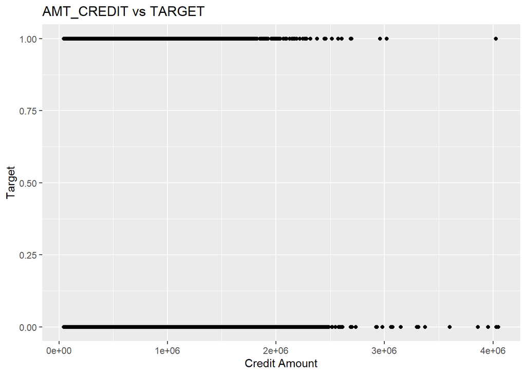

```r
ggplot(train_data, aes(x = AMT_CREDIT, y = TARGET)) +
  geom_point() +
  labs(title = "AMT_CREDIT vs TARGET", x = "Credit Amount", y = "Target")
```

#### 2.4 **Missing Data Exploration**

##### 2.4.1 Setup to discover missing values

```r
# Skim for a general overview
skim(train_data)
```

Data summary

| Name | train_data |
| --- | --- |
| Number of rows | 307511 |
| Number of columns | 122 |
| _______________________ |  |
| Column type frequency: |  |
| character | 16 |
| numeric | 106 |
| ________________________ |  |
| Group variables | None |

**Variable type: character**

| skim_variable | n_missing | complete_rate | min | max | empty | n_unique | whitespace |
| --- | --- | --- | --- | --- | --- | --- | --- |
| NAME_CONTRACT_TYPE | 0 | 1 | 10 | 15 | 0 | 2 | 0 |
| CODE_GENDER | 0 | 1 | 1 | 3 | 0 | 3 | 0 |
| FLAG_OWN_CAR | 0 | 1 | 1 | 1 | 0 | 2 | 0 |
| FLAG_OWN_REALTY | 0 | 1 | 1 | 1 | 0 | 2 | 0 |
| NAME_TYPE_SUITE | 0 | 1 | 0 | 15 | 1292 | 8 | 0 |
| NAME_INCOME_TYPE | 0 | 1 | 7 | 20 | 0 | 8 | 0 |
| NAME_EDUCATION_TYPE | 0 | 1 | 15 | 29 | 0 | 5 | 0 |
| NAME_FAMILY_STATUS | 0 | 1 | 5 | 20 | 0 | 6 | 0 |
| NAME_HOUSING_TYPE | 0 | 1 | 12 | 19 | 0 | 6 | 0 |
| OCCUPATION_TYPE | 0 | 1 | 0 | 21 | 96391 | 19 | 0 |
| WEEKDAY_APPR_PROCESS_START | 0 | 1 | 6 | 9 | 0 | 7 | 0 |
| ORGANIZATION_TYPE | 0 | 1 | 3 | 22 | 0 | 58 | 0 |
| FONDKAPREMONT_MODE | 0 | 1 | 0 | 21 | 210295 | 5 | 0 |
| HOUSETYPE_MODE | 0 | 1 | 0 | 16 | 154297 | 4 | 0 |
| WALLSMATERIAL_MODE | 0 | 1 | 0 | 12 | 156341 | 8 | 0 |
| EMERGENCYSTATE_MODE | 0 | 1 | 0 | 3 | 145755 | 3 | 0 |

**Variable type: numeric**

| skim_variable | n_missing | complete_rate | mean | sd | p0 | p25 | p50 | p75 | p100 | hist |
| --- | --- | --- | --- | --- | --- | --- | --- | --- | --- | --- |
| SK_ID_CURR | 0 | 1.00 | 278180.52 | 102790.18 | 100002.00 | 189145.50 | 278202.00 | 367142.50 | 456255.00 | ▇▇▇▇▇ |
| TARGET | 0 | 1.00 | 0.08 | 0.27 | 0.00 | 0.00 | 0.00 | 0.00 | 1.00 | ▇▁▁▁▁ |
| CNT_CHILDREN | 0 | 1.00 | 0.42 | 0.72 | 0.00 | 0.00 | 0.00 | 1.00 | 19.00 | ▇▁▁▁▁ |
| AMT_INCOME_TOTAL | 0 | 1.00 | 168797.92 | 237123.15 | 25650.00 | 112500.00 | 147150.00 | 202500.00 | 117000000.00 | ▇▁▁▁▁ |
| AMT_CREDIT | 0 | 1.00 | 599026.00 | 402490.78 | 45000.00 | 270000.00 | 513531.00 | 808650.00 | 4050000.00 | ▇▂▁▁▁ |
| AMT_ANNUITY | 12 | 1.00 | 27108.57 | 14493.74 | 1615.50 | 16524.00 | 24903.00 | 34596.00 | 258025.50 | ▇▁▁▁▁ |
| AMT_GOODS_PRICE | 278 | 1.00 | 538396.21 | 369446.46 | 40500.00 | 238500.00 | 450000.00 | 679500.00 | 4050000.00 | ▇▂▁▁▁ |
| REGION_POPULATION_RELATIVE | 0 | 1.00 | 0.02 | 0.01 | 0.00 | 0.01 | 0.02 | 0.03 | 0.07 | ▇▇▃▁▁ |
| DAYS_BIRTH | 0 | 1.00 | -16037.00 | 4363.99 | -25229.00 | -19682.00 | -15750.00 | -12413.00 | -7489.00 | ▃▆▇▇▅ |
| DAYS_EMPLOYED | 0 | 1.00 | 63815.05 | 141275.77 | -17912.00 | -2760.00 | -1213.00 | -289.00 | 365243.00 | ▇▁▁▁▂ |
| DAYS_REGISTRATION | 0 | 1.00 | -4986.12 | 3522.89 | -24672.00 | -7479.50 | -4504.00 | -2010.00 | 0.00 | ▁▁▂▅▇ |
| DAYS_ID_PUBLISH | 0 | 1.00 | -2994.20 | 1509.45 | -7197.00 | -4299.00 | -3254.00 | -1720.00 | 0.00 | ▁▆▇▆▅ |
| OWN_CAR_AGE | 202929 | 0.34 | 12.06 | 11.94 | 0.00 | 5.00 | 9.00 | 15.00 | 91.00 | ▇▁▁▁▁ |
| FLAG_MOBIL | 0 | 1.00 | 1.00 | 0.00 | 0.00 | 1.00 | 1.00 | 1.00 | 1.00 | ▁▁▁▁▇ |
| FLAG_EMP_PHONE | 0 | 1.00 | 0.82 | 0.38 | 0.00 | 1.00 | 1.00 | 1.00 | 1.00 | ▂▁▁▁▇ |
| FLAG_WORK_PHONE | 0 | 1.00 | 0.20 | 0.40 | 0.00 | 0.00 | 0.00 | 0.00 | 1.00 | ▇▁▁▁▂ |
| FLAG_CONT_MOBILE | 0 | 1.00 | 1.00 | 0.04 | 0.00 | 1.00 | 1.00 | 1.00 | 1.00 | ▁▁▁▁▇ |
| FLAG_PHONE | 0 | 1.00 | 0.28 | 0.45 | 0.00 | 0.00 | 0.00 | 1.00 | 1.00 | ▇▁▁▁▃ |
| FLAG_EMAIL | 0 | 1.00 | 0.06 | 0.23 | 0.00 | 0.00 | 0.00 | 0.00 | 1.00 | ▇▁▁▁▁ |
| CNT_FAM_MEMBERS | 2 | 1.00 | 2.15 | 0.91 | 1.00 | 2.00 | 2.00 | 3.00 | 20.00 | ▇▁▁▁▁ |
| REGION_RATING_CLIENT | 0 | 1.00 | 2.05 | 0.51 | 1.00 | 2.00 | 2.00 | 2.00 | 3.00 | ▁▁▇▁▂ |
| REGION_RATING_CLIENT_W_CITY | 0 | 1.00 | 2.03 | 0.50 | 1.00 | 2.00 | 2.00 | 2.00 | 3.00 | ▁▁▇▁▂ |
| HOUR_APPR_PROCESS_START | 0 | 1.00 | 12.06 | 3.27 | 0.00 | 10.00 | 12.00 | 14.00 | 23.00 | ▁▃▇▆▁ |
| REG_REGION_NOT_LIVE_REGION | 0 | 1.00 | 0.02 | 0.12 | 0.00 | 0.00 | 0.00 | 0.00 | 1.00 | ▇▁▁▁▁ |
| REG_REGION_NOT_WORK_REGION | 0 | 1.00 | 0.05 | 0.22 | 0.00 | 0.00 | 0.00 | 0.00 | 1.00 | ▇▁▁▁▁ |
| LIVE_REGION_NOT_WORK_REGION | 0 | 1.00 | 0.04 | 0.20 | 0.00 | 0.00 | 0.00 | 0.00 | 1.00 | ▇▁▁▁▁ |
| REG_CITY_NOT_LIVE_CITY | 0 | 1.00 | 0.08 | 0.27 | 0.00 | 0.00 | 0.00 | 0.00 | 1.00 | ▇▁▁▁▁ |
| REG_CITY_NOT_WORK_CITY | 0 | 1.00 | 0.23 | 0.42 | 0.00 | 0.00 | 0.00 | 0.00 | 1.00 | ▇▁▁▁▂ |
| LIVE_CITY_NOT_WORK_CITY | 0 | 1.00 | 0.18 | 0.38 | 0.00 | 0.00 | 0.00 | 0.00 | 1.00 | ▇▁▁▁▂ |
| EXT_SOURCE_1 | 173378 | 0.44 | 0.50 | 0.21 | 0.01 | 0.33 | 0.51 | 0.68 | 0.96 | ▂▇▇▇▃ |

[output cut: 76 more lines]

```r
# Checking missing values
library(dplyr)
train_data %>%
  summarise(across(everything(), ~ sum(is.na(.))))
```

```
##   SK_ID_CURR TARGET NAME_CONTRACT_TYPE CODE_GENDER FLAG_OWN_CAR FLAG_OWN_REALTY
## 1          0      0                  0           0            0               0
##   CNT_CHILDREN AMT_INCOME_TOTAL AMT_CREDIT AMT_ANNUITY AMT_GOODS_PRICE
## 1            0                0          0          12             278
##   NAME_TYPE_SUITE NAME_INCOME_TYPE NAME_EDUCATION_TYPE NAME_FAMILY_STATUS
## 1               0                0                   0                  0
##   NAME_HOUSING_TYPE REGION_POPULATION_RELATIVE DAYS_BIRTH DAYS_EMPLOYED
## 1                 0                          0          0             0
##   DAYS_REGISTRATION DAYS_ID_PUBLISH OWN_CAR_AGE FLAG_MOBIL FLAG_EMP_PHONE
## 1                 0               0      202929          0              0
##   FLAG_WORK_PHONE FLAG_CONT_MOBILE FLAG_PHONE FLAG_EMAIL OCCUPATION_TYPE
## 1               0                0          0          0               0
##   CNT_FAM_MEMBERS REGION_RATING_CLIENT REGION_RATING_CLIENT_W_CITY
## 1               2                    0                           0
##   WEEKDAY_APPR_PROCESS_START HOUR_APPR_PROCESS_START REG_REGION_NOT_LIVE_REGION
## 1                          0                       0                          0
##   REG_REGION_NOT_WORK_REGION LIVE_REGION_NOT_WORK_REGION REG_CITY_NOT_LIVE_CITY
## 1                          0                           0                      0
##   REG_CITY_NOT_WORK_CITY LIVE_CITY_NOT_WORK_CITY ORGANIZATION_TYPE EXT_SOURCE_1
## 1                      0                       0                 0       173378
##   EXT_SOURCE_2 EXT_SOURCE_3 APARTMENTS_AVG BASEMENTAREA_AVG
## 1          660        60965         156061           179943
##   YEARS_BEGINEXPLUATATION_AVG YEARS_BUILD_AVG COMMONAREA_AVG ELEVATORS_AVG
## 1                      150007          204488         214865        163891
##   ENTRANCES_AVG FLOORSMAX_AVG FLOORSMIN_AVG LANDAREA_AVG LIVINGAPARTMENTS_AVG
## 1        154828        153020        208642       182590               210199
##   LIVINGAREA_AVG NONLIVINGAPARTMENTS_AVG NONLIVINGAREA_AVG APARTMENTS_MODE
## 1         154350                  213514            169682          156061
##   BASEMENTAREA_MODE YEARS_BEGINEXPLUATATION_MODE YEARS_BUILD_MODE
## 1            179943                       150007           204488
##   COMMONAREA_MODE ELEVATORS_MODE ENTRANCES_MODE FLOORSMAX_MODE FLOORSMIN_MODE
## 1          214865         163891         154828         153020         208642
##   LANDAREA_MODE LIVINGAPARTMENTS_MODE LIVINGAREA_MODE NONLIVINGAPARTMENTS_MODE
## 1        182590                210199          154350                   213514
##   NONLIVINGAREA_MODE APARTMENTS_MEDI BASEMENTAREA_MEDI
## 1             169682          156061            179943
##   YEARS_BEGINEXPLUATATION_MEDI YEARS_BUILD_MEDI COMMONAREA_MEDI ELEVATORS_MEDI
## 1                       150007           204488          214865         163891
##   ENTRANCES_MEDI FLOORSMAX_MEDI FLOORSMIN_MEDI LANDAREA_MEDI
## 1         154828         153020         208642        182590
```

[output cut: 9 more lines]

```
## 1                      1               0               0               0
##   FLAG_DOCUMENT_5 FLAG_DOCUMENT_6 FLAG_DOCUMENT_7 FLAG_DOCUMENT_8
## 1               0               0               0               0
##   FLAG_DOCUMENT_9 FLAG_DOCUMENT_10 FLAG_DOCUMENT_11 FLAG_DOCUMENT_12
## 1               0                0                0                0
##   FLAG_DOCUMENT_13 FLAG_DOCUMENT_14 FLAG_DOCUMENT_15 FLAG_DOCUMENT_16
## 1                0                0                0                0
##   FLAG_DOCUMENT_17 FLAG_DOCUMENT_18 FLAG_DOCUMENT_19 FLAG_DOCUMENT_20
## 1                0                0                0                0
##   FLAG_DOCUMENT_21 AMT_REQ_CREDIT_BUREAU_HOUR AMT_REQ_CREDIT_BUREAU_DAY
## 1                0                      41519                     41519
##   AMT_REQ_CREDIT_BUREAU_WEEK AMT_REQ_CREDIT_BUREAU_MON
## 1                      41519                     41519
##   AMT_REQ_CREDIT_BUREAU_QRT AMT_REQ_CREDIT_BUREAU_YEAR
## 1                     41519                      41519
```

```r
# Using janitor for a cleaner view of missing data
train_data_clean <- train_data %>% remove_empty("cols")
```

```r
# Removing columns with more than 50% missing values
train_data <- train_data[, colMeans(is.na(train_data)) < 0.5]

# Imputing with median
train_data$AMT_INCOME_TOTAL[is.na(train_data$AMT_INCOME_TOTAL)] <- median(train_data$AMT_INCOME_TOTAL, na.rm = TRUE)
```

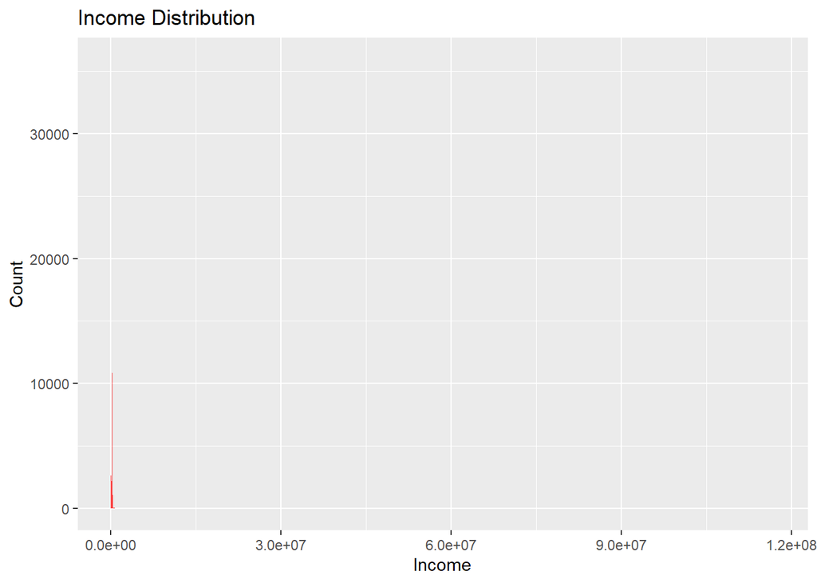

```r
ggplot(train_data, aes(x = AMT_INCOME_TOTAL)) +
  geom_histogram(binwidth = 5000, fill = "red", alpha = 0.7) +
  labs(title = "Income Distribution", x = "Income", y = "Count")
```

```r
# Converting categorical variables into factors
train_data$CODE_GENDER <- as.factor(train_data$CODE_GENDER)

# For models requiring dummy variables
train_data <- model.matrix(~ CODE_GENDER + FLAG_OWN_CAR, data = train_data)
```

### 3 **Additional Questions to Guide Exploration**

Some questions you can explore during EDA include:

- Is the data balanced or imbalanced with respect to the target variable (loan default)?
- What are the relationships between key features (e.g., loan amount, income) and the target variable?
- Which features are the strongest predictors of loan default?
- Are there any significant data quality issues, such as missing or outlier values?
- Does the data need preprocessing, such as normalization or encoding of categorical variables?
- How are demographic variables (e.g., age, family status) related to loan default?
- What trends can be seen with credit amount, loan annuity, and income total?

### 4 **Data Description**

Your dataset includes information about loan applicants, such as demographic information (e.g., age, gender), financial information (e.g., income, credit amount), and loan application details. The file `application_train.csv` is the primary dataset, and additional data files (such as `bureau.csv`) can be used to enrich the analysis by joining based on `SK_ID_CURR`.

**Summary of the Data:**

- The dataset contains both numeric and categorical variables.
- Key variables include `AMT_CREDIT`, `AMT_INCOME_TOTAL`, `AMT_ANNUITY`, and `DAYS_BIRTH`.
- The target variable is `TARGET`, which indicates loan repayment status.

### 5 **Missing Data**

During the data exploration, you might encounter missing values in several columns. For instance, columns related to property or financial information may have missing values for some applicants. Addressing missing data is crucial for accurate model development.

**Proposed Solutions:**

- For columns with a significant portion of missing data (e.g., more than 50%), consider dropping these columns.
- For columns with fewer missing values, consider imputing with median or mean values (for numerical columns) or the most frequent value (for categorical columns).
- You can also consider more sophisticated imputation methods like k-nearest neighbors or predictive modeling.